# Model 2: COVID Deterioration

# 1 Model 2: Sample-Level Prediction of COVID Deterioration

This model predicts future COVID deterioration from the metabolomic and clinical profile available at a single sample/presentation.

Multiple samples from the same patient are allowed as separate rows because each sample represents a separate clinical presentation. To prevent patient-level leakage, grouped cross-validation is used so all samples from the same patient stay in the same fold.

# 2 Load Data

[output not shown]

[output cut: 717 more lines]

[output not shown]

```
Raw data shape: (700, 768)
```

```
Unique patients: 339
```

```
===== mortality_status =====
mortality_status
Alive       523
Deceased    177
Name: count, dtype: int64

===== x30_day_mortality =====
x30_day_mortality
0.0    609
1.0     91
Name: count, dtype: int64

===== x60_day_mortality =====
x60_day_mortality
NaN    567
1      133
Name: count, dtype: int64

===== x90_day_mortality =====
x90_day_mortality
NaN    553
1      147
Name: count, dtype: int64
```

# 3 Create Sample-Level Future Deterioration Target

```
Sample-level target counts:
```

```
deterioration_binary
stable           353
deteriorating    240
Name: count, dtype: int64
```

```
Patients retained:
```

```
339
```

# 4 Define Candidate Predictor Groups

```
Metabolite features: 707
```

```
Clinical features: 25
```

```
Time features: 1
```

```
Total candidate predictors: 733
```

# 5 Clean Model Dataset

```
Final model dataframe shape: (593, 735)
```

```
Dropped high-missing features: 0
```

```
Dropped constant features: 0
```

```
Final class counts:
```

```
deterioration_binary
stable           353
deteriorating    240
Name: count, dtype: int64
```

```
Final unique patients:
```

```
339
```

# 6 Prepare Modelling Objects

```
Class mapping:
```

```
stable -> 0
```

```
deteriorating -> 1
```

```
Samples: 593
```

```
Predictors: 733
```

```
Unique patient groups: 339
```

```
Class proportions:
```

```
deterioration_binary
stable           0.595278
deteriorating    0.404722
Name: proportion, dtype: float64
```

```
XGBoost scale_pos_weight: 1.471
```

# 7 Class Distribution Plot

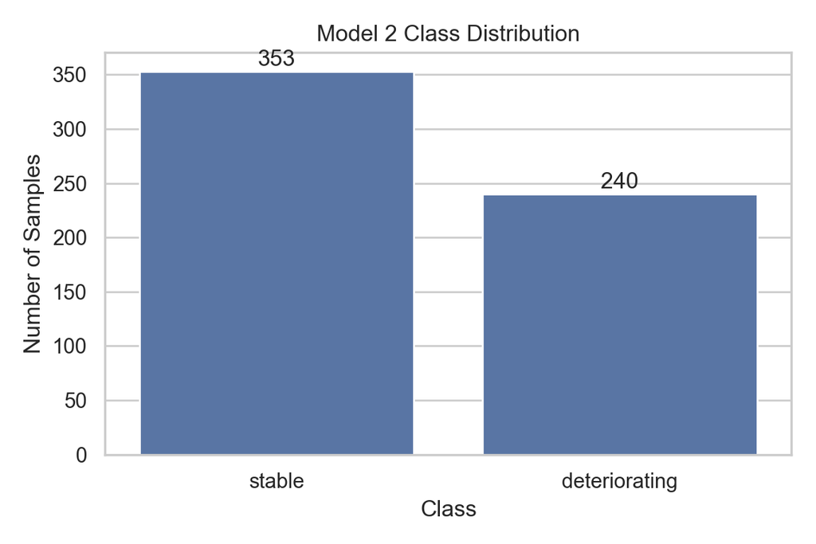

# 8 Define Cache Key

```
Cache key: 0cac3af4b5
```

# 9 Feature Selection Object

# 10 Define Six Models

```
Models included:
```

```
- Extra Trees
- XGBoost
- Elastic Net Logistic Regression
- SVM RBF
- Gaussian Naive Bayes
- MLP Neural Network
```

# 11 Cached Hyperparameter Tuning

```
Loading cached tuned model: Extra Trees

Loading cached tuned model: XGBoost

Loading cached tuned model: Elastic Net Logistic Regression

Loading cached tuned model: SVM RBF

Loading cached tuned model: Gaussian Naive Bayes

Loading cached tuned model: MLP Neural Network
```

```
Hyperparameter tuning summary:
```

```
                                Best CV Macro F1  \
Elastic Net Logistic Regression         0.778423
MLP Neural Network                      0.774124
Extra Trees                             0.772471
XGBoost                                 0.763127
SVM RBF                                 0.761823
Gaussian Naive Bayes                    0.695554

                                                                       Best Params
Elastic Net Logistic Regression  {'feature_selection__max_features': 100, 'mode...
MLP Neural Network               {'feature_selection__max_features': 50, 'model...
Extra Trees                      {'feature_selection__max_features': 50, 'model...
XGBoost                          {'feature_selection__max_features': 50, 'model...
SVM RBF                          {'feature_selection__max_features': 75, 'model...
Gaussian Naive Bayes             {'feature_selection__max_features': 75, 'model...
```

# 12 Final Grouped Cross-Validated Model Comparison

```
Loading cached final CV results.
```

```
Final grouped-CV model comparison:
```

```
                                 Balanced Accuracy Mean  Balanced Accuracy SD  \
Elastic Net Logistic Regression                0.784110              0.040746
MLP Neural Network                             0.776268              0.032271
Extra Trees                                    0.776294              0.041386
XGBoost                                        0.768220              0.033557
SVM RBF                                        0.771701              0.028908
Gaussian Naive Bayes                           0.704931              0.039347

                                 Macro F1 Mean  Macro F1 SD  AUROC Mean  \
Elastic Net Logistic Regression       0.778423     0.035489    0.862896
MLP Neural Network                    0.774124     0.031389    0.840505
Extra Trees                           0.772471     0.039475    0.856868
XGBoost                               0.763127     0.029998    0.845218
SVM RBF                               0.761823     0.025342    0.843944
Gaussian Naive Bayes                  0.695554     0.046502    0.794326

                                 AUROC SD  Precision Mean  Precision SD  \
Elastic Net Logistic Regression  0.038335        0.721504      0.046395
MLP Neural Network               0.031266        0.761135      0.082363
Extra Trees                      0.030168        0.730975      0.070837
XGBoost                          0.032551        0.710185      0.061000
SVM RBF                          0.036419        0.690341      0.058565
Gaussian Naive Bayes             0.041377        0.648539      0.109817

                                 Recall Mean  Recall SD
Elastic Net Logistic Regression     0.769504   0.082941
MLP Neural Network                  0.705857   0.086434
Extra Trees                         0.742282   0.062255
XGBoost                             0.742448   0.051417
SVM RBF                             0.783163   0.070506
Gaussian Naive Bayes                0.673926   0.092451
```

# 13 Model Comparison Plots

[output not shown]

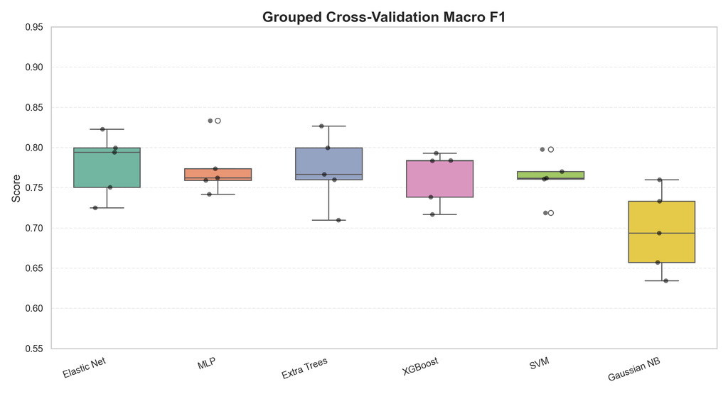

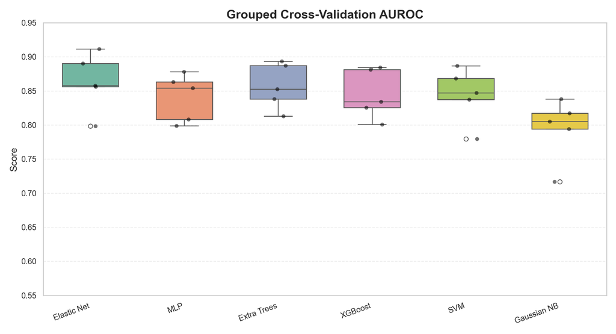

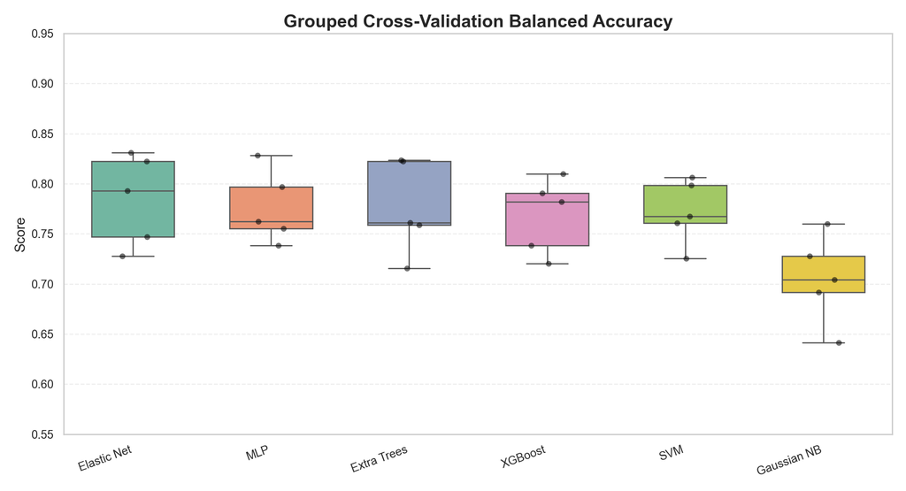

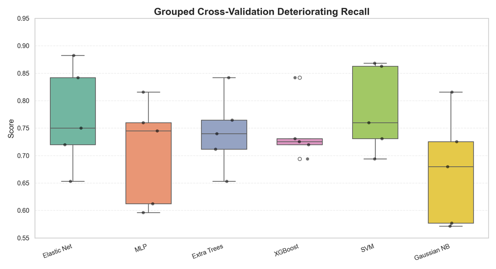

```
(0.63, 0.84)
```

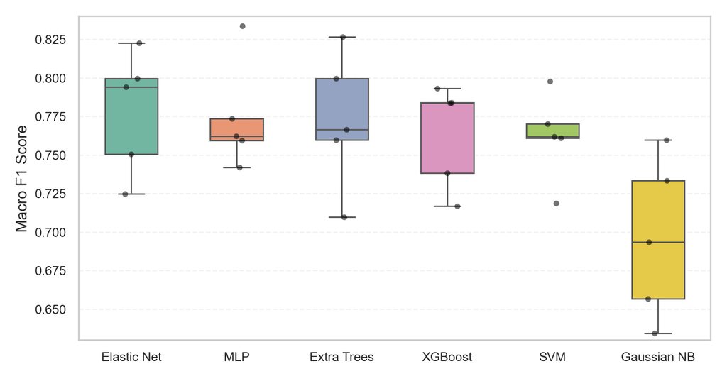

# 14 Select Best Model

```
Best final model: Elastic Net Logistic Regression
```

```
Best tuned parameters:
```

```
{'feature_selection__max_features': 100, 'model__C': 0.05, 'model__l1_ratio': 0.25}
```

# 15 Cross-Validated Predictions for Best Model

```
Loading cached cross-validated predictions.
```

# 16 Default Threshold Performance

```
Classification report using default threshold:
```

```
               precision    recall  f1-score   support

       stable       0.83      0.80      0.82       353
deteriorating       0.72      0.77      0.74       240

     accuracy                           0.79       593
    macro avg       0.78      0.78      0.78       593
 weighted avg       0.79      0.79      0.79       593
```

```
Grouped-CV AUROC: 0.856
```

```
Grouped-CV Average Precision: 0.803
```

```
<sklearn.metrics._plot.confusion_matrix.ConfusionMatrixDisplay object at 0x00000237AA9800E0>
```

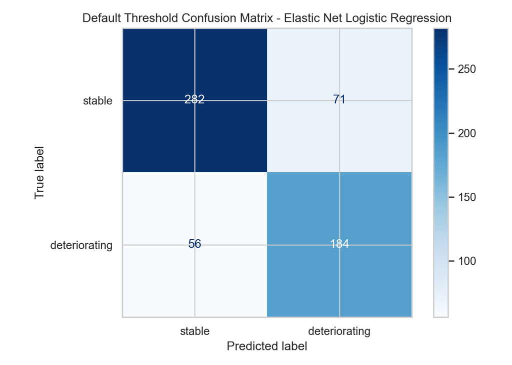

# 17 Threshold Tuning

```
Best threshold based on macro F1:
```

```
threshold                  0.520000
macro_f1                   0.781696
balanced_accuracy          0.782265
deteriorating_precision    0.736626
deteriorating_recall       0.745833
stable_recall              0.818697
Name: 47, dtype: float64
```

```
Classification report using tuned threshold:
```

```
               precision    recall  f1-score   support

       stable       0.83      0.82      0.82       353
deteriorating       0.74      0.75      0.74       240

     accuracy                           0.79       593
    macro avg       0.78      0.78      0.78       593
 weighted avg       0.79      0.79      0.79       593
```

```
<sklearn.metrics._plot.confusion_matrix.ConfusionMatrixDisplay object at 0x00000237AFC54200>
```

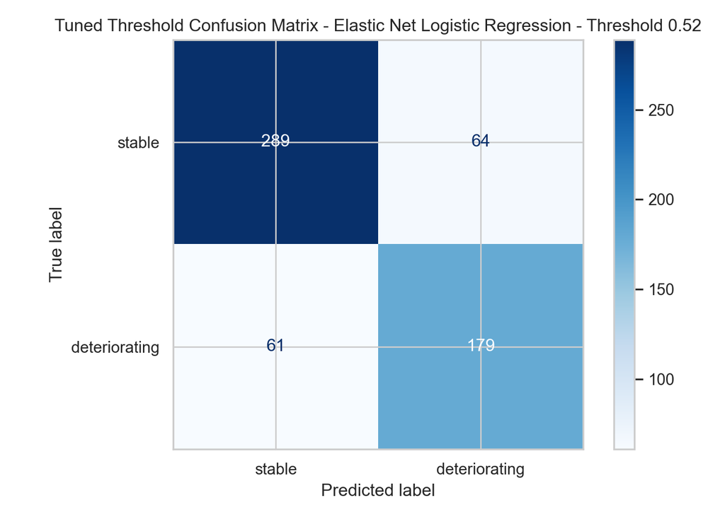

# 18 Threshold Sensitivity Plot

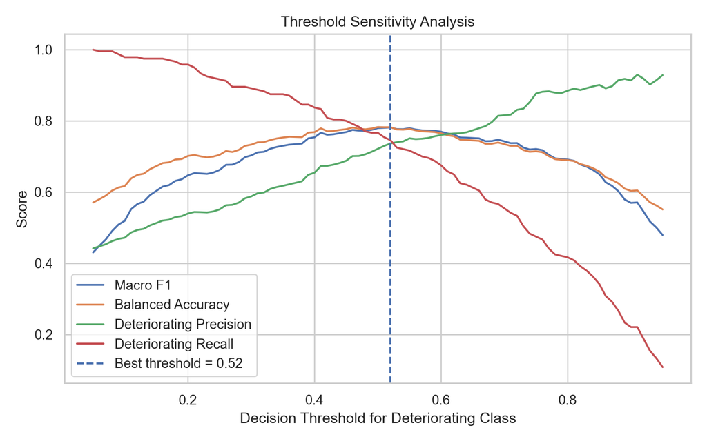

# 19 ROC Curve

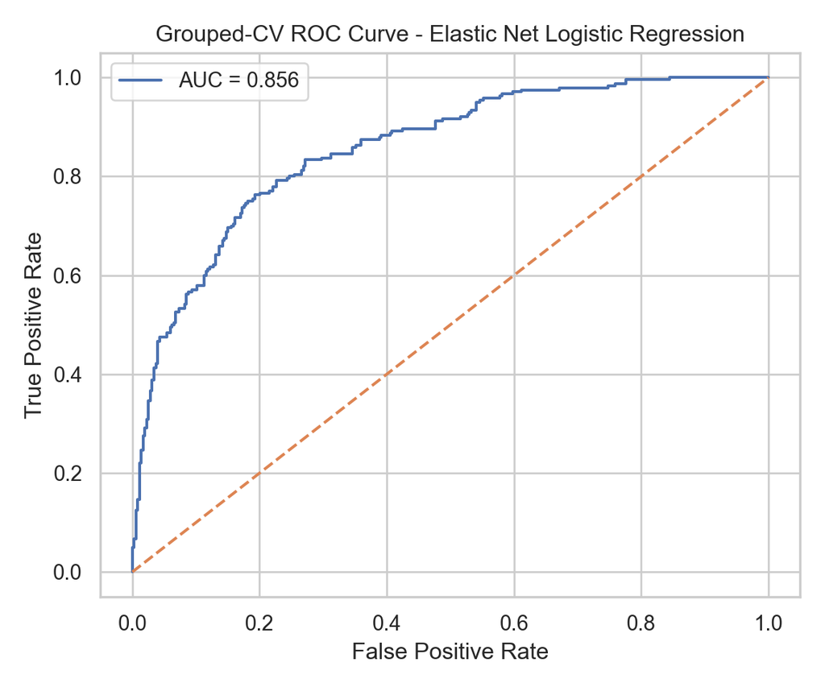

# 20 Precision-Recall Curve

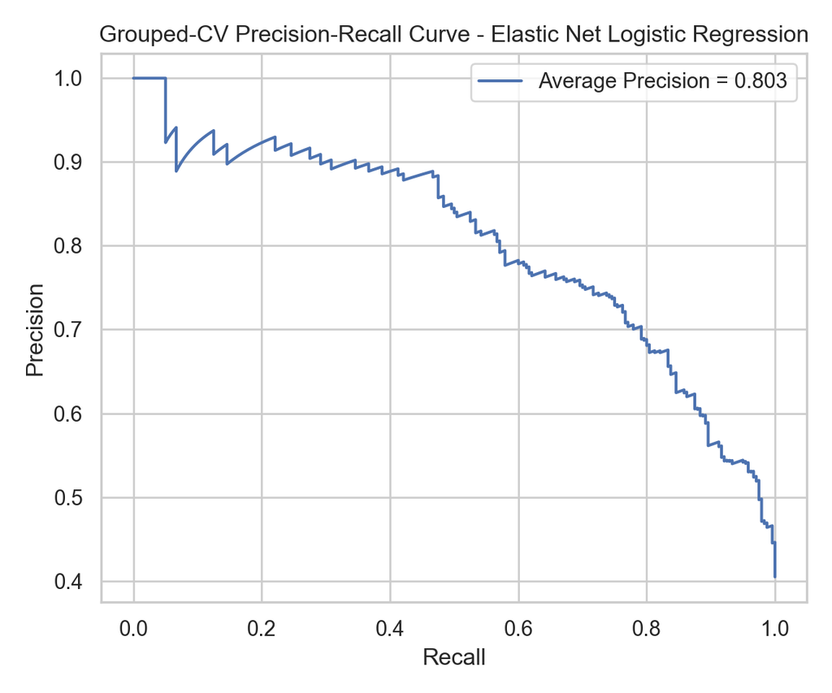

# 21 Probability Distribution Plot

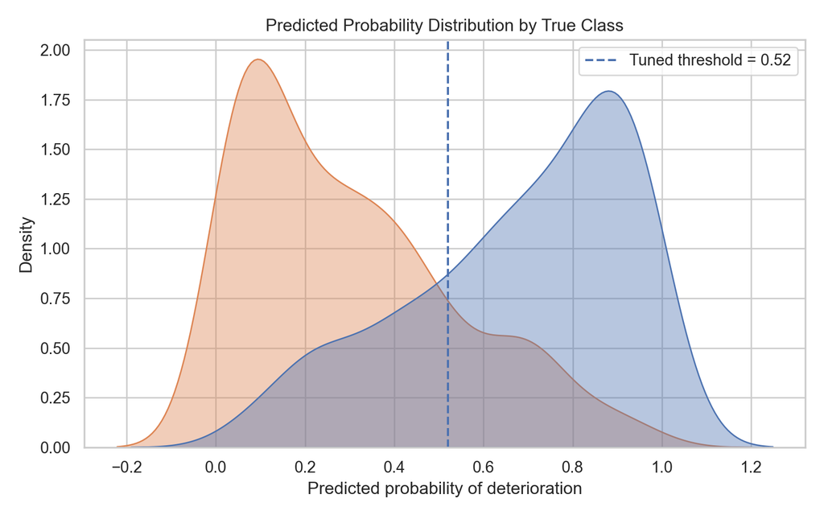

# 22 Feature Importance

```
Pipeline(steps=[('imputer', SimpleImputer(strategy='median')),
                ('scaler', StandardScaler()),
                ('feature_selection',
                 SelectFromModel(estimator=ExtraTreesClassifier(class_weight='balanced',
                                                                min_samples_leaf=2,
                                                                n_estimators=250,
                                                                n_jobs=1,
                                                                random_state=42),
                                 max_features=100)),
                ('model',
                 LogisticRegression(C=0.05, class_weight='balanced',
                                    l1_ratio=0.25, max_iter=5000,
                                    penalty='elasticnet', random_state=42,
                                    solver='saga'))])
```

```
Top selected predictors:
```

```
                             feature  importance
27        F2_Cer_NS.d18.2_16.0_16.67    0.311328
6                lymphocyte_absolute    0.302037
64                 F2_TG.52.5_23.144    0.294485
1                                crp    0.276657
60                 F2_PE.38.5_17.129    0.269350
4                                age    0.269017
0         age_at_symptom_onset_years    0.268979
65                   F2_TG.54.2_24.3    0.237464
11                               il8    0.223276
74                F3_L.Threonic.acid    0.216430
71  F3_DL.4.Hydroxyphenyllactic.acid    0.204370
94              F4_N4.Acetylcytidine    0.197655
12            F1_Cer_NS.d43.1.21.881    0.196035
23                 F2_CE.20.4_24.252    0.187939
```

[output cut: 16 more lines]

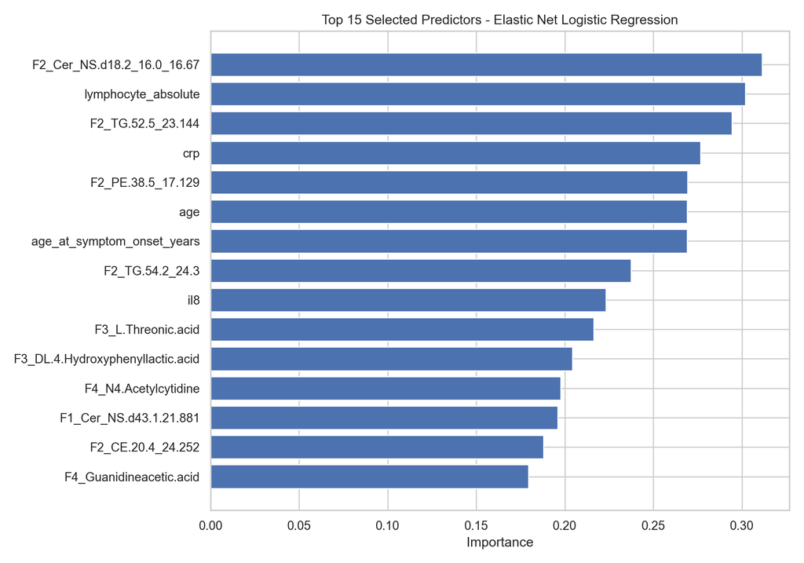

# 23 Save Report Tables

```
Saved report tables:
```

```
- model2_grouped_cv_results.csv
```

```
- model2_tuned_hyperparameters.csv
```

```
- model2_threshold_sensitivity.csv
```

```
- model2_feature_importance.csv
```

# 24 Final Summary

```
================ FINAL SUMMARY ================
```

```
Aim: Predict future deterioration from one sample/presentation
```

```
Leakage control: GroupKFold by patient_id
```

```
Samples: 593
```

```
Unique patients: 339
```

```
Predictors before selection: 733
```

```
Best model: Elastic Net Logistic Regression
```

```
Grouped-CV AUROC: 0.856
```

```
Grouped-CV Average Precision: 0.803
```

```
Default threshold Macro F1: 0.78
```

```
Best tuned threshold: 0.52
```

```
Tuned threshold Macro F1: 0.782
```

```
Best model grouped CV performance:
```

```
                                 Balanced Accuracy Mean  Balanced Accuracy SD  Macro F1 Mean  Macro F1 SD  AUROC Mean  AUROC SD  Precision Mean  Precision SD  Recall Mean  Recall SD
Elastic Net Logistic Regression                 0.78411              0.040746       0.778423     0.035489    0.862896  0.038335        0.721504      0.046395     0.769504   0.082941
```

# 25 Interpretation Notes

The final model treats each blood sample as a separate clinical presentation, allowing multiple time points from the same patient to contribute separate observations. Grouped cross-validation was used so all samples from the same patient were kept in the same fold, preventing patient-level leakage.

The modelling workflow compares six distinct modelling paradigms: tree ensembles, gradient boosting, sparse linear modelling, kernel methods, probabilistic classification, and neural networks. Candidate clinical and metabolomic predictors are first defined using dataset structure and domain relevance, while final feature selection occurs inside the machine learning pipeline using tree-based selection within cross-validation.

The best model should be interpreted using AUROC, average precision, macro F1, balanced accuracy, and class-specific recall rather than accuracy alone, because the clinical problem involves imbalance and the deteriorating class is the class of interest.

```
                                 Balanced Accuracy Mean  Balanced Accuracy SD  Macro F1 Mean  Macro F1 SD  AUROC Mean  AUROC SD  Precision Mean  Precision SD  Recall Mean  Recall SD
Elastic Net Logistic Regression                   0.784                 0.041          0.778        0.035       0.863     0.038           0.722         0.046        0.770      0.083
MLP Neural Network                                0.776                 0.032          0.774        0.031       0.841     0.031           0.761         0.082        0.706      0.086
Extra Trees                                       0.776                 0.041          0.772        0.039       0.857     0.030           0.731         0.071        0.742      0.062
XGBoost                                           0.768                 0.034          0.763        0.030       0.845     0.033           0.710         0.061        0.742      0.051
SVM RBF                                           0.772                 0.029          0.762        0.025       0.844     0.036           0.690         0.059        0.783      0.071
Gaussian Naive Bayes                              0.705                 0.039          0.696        0.047       0.794     0.041           0.649         0.110        0.674      0.092
```

[output not shown]

```
Pipeline(steps=[('imputer', SimpleImputer(strategy='median')),
                ('scaler', StandardScaler()),
                ('feature_selection',
                 SelectFromModel(estimator=ExtraTreesClassifier(class_weight='balanced',
                                                                min_samples_leaf=2,
                                                                n_estimators=250,
                                                                n_jobs=1,
                                                                random_state=42),
                                 max_features=100)),
                ('model',
                 LogisticRegression(C=0.05, class_weight='balanced',
                                    l1_ratio=0.25, max_iter=5000,
                                    penalty='elasticnet', random_state=42,
                                    solver='saga'))])
```

```
Selected features before coefficient filtering:
```

```
100
```

```
Saved:
```

```
model1_concise_features.csv
```

```
['C:/Users/manna/OneDrive/Desktop/model2_pipeline.pkl']
```

```
['C:/Users/manna/OneDrive/Desktop/model2_full_features.pkl']
```

```
['C:/Users/manna/OneDrive/Desktop/model2_threshold.pkl']
```

```
Saved Model 2 backend files:
```

```
- model2_pipeline.pkl
```

```
- model2_full_features.pkl
```

```
- model2_threshold.pkl
```

```
===== REAL STABLE SAMPLE =====
```

```
age_at_symptom_onset_years: 70.9
crp: 208.4
d_dimer: -1.0
neutrophil_percent: 66.4
age: 70.9
neutrophil_absolute: 7.5
lymphocyte_absolute: 3.0
lymphocyte_percent: 26.7
il1ra: 59.35965373
il2r: 388.3641296
mig: 163.7772012
il8: 17.28513739
F1_Cer_NS.d43.1.21.881: 24637.9343
F1_LPC.16.0.0.0.5.185: 421402.1972
F1_LPC.18.0.0.0.7.599: 68243.0693
F1_LPC.18.2.0.0.4.227: 78568.2061
F1_LPC.20.4.0.0.4.062: 52462.3752
F1_LPE.18.0.7.653: 145287.2078
F1_PC.18.2_20.4.15.83: 145553.0838
F1_PE.16.0_18.1.17.818: 880788.269
F1_PE.18.0_18.1.18.965: 297484.7254
F2_ACar.10.1_1.716: 407082.8917
F2_CE.20.3_24.516: 614398.5074
F2_CE.20.4_24.252: 20744960.5
F2_Cer_NS.d18.1_16.0_17.788: 475353.1017
F2_Cer_NS.d18.1_18.0_18.975: 152937.4451
F2_Cer_NS.d18.1_24.1_20.867: 1234931.062
F2_Cer_NS.d18.2_16.0_16.67: 104276.8546
F2_Cer_NS.d18.2_24.1_20.136: 395109.7886
F2_LPC.0.0.14.0_3.126: 28875.1723
F2_LPC.0.0.16.0_4.715: 3044251.159
F2_LPC.0.0.16.1_3.451: 74132.668
F2_LPC.0.0.18.0_6.997: 221045.3683
F2_LPC.0.0.18.2_3.873: 822868.091
F2_LPC.0.0.22.6_3.703: 511838.9131
F2_LPC.14.0.0.0_3.387: 222188.5551
F2_LPC.15.0.0.0_4.164: 104050.86
F2_LPC.16.0.0.0_5.147: 29514165.74
F2_LPC.16.1.0.0_3.734: 733272.9246
F2_LPC.17.0.0.0_6.28: 122091.484
```

[output cut: 45 more lines]

```
F4_X6.Methyl.1.2.4.triazolo.4.3.b.pyridazin.8.ol: 2436495.448
F4_Creatine: 12895602.07
F4_DL.Tryptophan: 3466927.506
F4_Eleostearic.acid: 881961.0086
F4_Guanidineacetic.acid: 386998.6343
F4_Hexanoylcarnitine: 2505629.402
F4_Kynurenine: 3047611.056
F4_L.Serine: 406072.5781
F4_N2_N2.Dimethylguanosine: 1407367.655
F4_N4.Acetylcytidine: 956602.2694
F4_N_N.DIMETHYLARGININE: 471834.9866
F4_Octanoyl.L.Carnitine: 4760373.001
F4_Prolylleucine: 13348880.85
F4_Skatole: 63139.9941
F4_trans.3.Indoleacrylic.acid: 1434346.678
```

```
===== REAL DETERIORATING SAMPLE =====
```

```
age_at_symptom_onset_years: 80.8
crp: 225.9
d_dimer: 1670.0
neutrophil_percent: 93.1
age: 80.8
neutrophil_absolute: 8.2
lymphocyte_absolute: 0.3
lymphocyte_percent: 3.0
il1ra: 1048.239677
il2r: 124.3491115
mig: 84.900486
il8: 25.72906886
F1_Cer_NS.d43.1.21.881: 93760.8008
F1_LPC.16.0.0.0.5.185: 534556.9387
F1_LPC.18.0.0.0.7.599: 102906.8677
F1_LPC.18.2.0.0.4.227: 45804.2557
F1_LPC.20.4.0.0.4.062: 77019.0913
F1_LPE.18.0.7.653: 135020.3299
F1_PC.18.2_20.4.15.83: 126530.0765
F1_PE.16.0_18.1.17.818: 828696.0274
F1_PE.18.0_18.1.18.965: 448314.8638
F2_ACar.10.1_1.716: 87207.9326
F2_CE.20.3_24.516: 2945677.104
F2_CE.20.4_24.252: 56304697.48
F2_Cer_NS.d18.1_16.0_17.788: 873428.182
F2_Cer_NS.d18.1_18.0_18.975: 503705.2235
F2_Cer_NS.d18.1_24.1_20.867: 2867096.143
F2_Cer_NS.d18.2_16.0_16.67: 178917.8778
F2_Cer_NS.d18.2_24.1_20.136: 686934.2605
F2_LPC.0.0.14.0_3.126: 31917.129
F2_LPC.0.0.16.0_4.715: 4616631.474
F2_LPC.0.0.16.1_3.451: 69963.126
F2_LPC.0.0.18.0_6.997: 480303.4223
F2_LPC.0.0.18.2_3.873: 483052.7365
F2_LPC.0.0.22.6_3.703: 613129.2584
F2_LPC.14.0.0.0_3.387: 246450.5909
F2_LPC.15.0.0.0_4.164: 222297.6935
F2_LPC.16.0.0.0_5.147: 40171493.97
F2_LPC.16.1.0.0_3.734: 746992.1733
F2_LPC.17.0.0.0_6.28: 257212.2779
```

[output cut: 45 more lines]

```
F4_X6.Methyl.1.2.4.triazolo.4.3.b.pyridazin.8.ol: 522953.9271
F4_Creatine: 18481049.27
F4_DL.Tryptophan: 6827841.175
F4_Eleostearic.acid: 1106082.335
F4_Guanidineacetic.acid: 349253.5383
F4_Hexanoylcarnitine: 710486.7761
F4_Kynurenine: 2556331.604
F4_L.Serine: 513982.8917
F4_N2_N2.Dimethylguanosine: 466564.8019
F4_N4.Acetylcytidine: 879394.6294
F4_N_N.DIMETHYLARGININE: 140506.2187
F4_Octanoyl.L.Carnitine: 1134588.181
F4_Prolylleucine: 1537132.326
F4_Skatole: 104489.0252
F4_trans.3.Indoleacrylic.acid: 2943955.749
```